# Research on Education and Census Data

Kathy Wu and Chelsea Lu

December 09, 2021

**Introduction to the Datasets**

**Census Data**

```r
state.name <- c(state.name, "District of Columbia")
state.abb <- c(state.abb, "DC")
## read in census data
census <- read_csv("./acs2017_county_data.csv") %>%
  select(-CountyId, -ChildPoverty, -Income, -IncomeErr, -IncomePerCap, -IncomePerCapErr) %>%
  mutate(State = state.abb[match(`State`, state.name)]) %>%
  filter(State != "PR")
head(census)
```

| State | County | TotalPop | Men | Women | Hispanic | White | Black | Native | Asian | Pacific | VotingAgeCitizen | Poverty | Professional | Service | Office | Construction | Production | Drive | Carpool | Transit | Walk | OtherTransp | WorkAtHome | MeanCommute | Employed | PrivateWork | PublicWork | SelfEmployed | FamilyWork | … |
| --- | --- | --- | --- | --- | --- | --- | --- | --- | --- | --- | --- | --- | --- | --- | --- | --- | --- | --- | --- | --- | --- | --- | --- | --- | --- | --- | --- | --- | --- | --- |
| AL | Autauga County | 55036 | 26899 | 28137 | 2.7 | 75.4 | 18.9 | 0.3 | 0.9 | 0 | 41016 | 13.7 | 35.3 | 18.0 | 23.2 | 8.1 | 15.4 | 86.0 | 9.6 | 0.1 | 0.6 | 1.3 | 2.5 | 25.8 | 24112 | 74.1 | 20.2 | 5.6 | 0.1 | … |
| AL | Baldwin County | 203360 | 99527 | 103833 | 4.4 | 83.1 | 9.5 | 0.8 | 0.7 | 0 | 155376 | 11.8 | 35.7 | 18.2 | 25.6 | 9.7 | 10.8 | 84.7 | 7.6 | 0.1 | 0.8 | 1.1 | 5.6 | 27.0 | 89527 | 80.7 | 12.9 | 6.3 | 0.1 | … |
| AL | Barbour County | 26201 | 13976 | 12225 | 4.2 | 45.7 | 47.8 | 0.2 | 0.6 | 0 | 20269 | 27.2 | 25.0 | 16.8 | 22.6 | 11.5 | 24.1 | 83.4 | 11.1 | 0.3 | 2.2 | 1.7 | 1.3 | 23.4 | 8878 | 74.1 | 19.1 | 6.5 | 0.3 | … |
| AL | Bibb County | 22580 | 12251 | 10329 | 2.4 | 74.6 | 22.0 | 0.4 | 0.0 | 0 | 17662 | 15.2 | 24.4 | 17.6 | 19.7 | 15.9 | 22.4 | 86.4 | 9.5 | 0.7 | 0.3 | 1.7 | 1.5 | 30.0 | 8171 | 76.0 | 17.4 | 6.3 | 0.3 | … |
| AL | Blount County | 57667 | 28490 | 29177 | 9.0 | 87.4 | 1.5 | 0.3 | 0.1 | 0 | 42513 | 15.6 | 28.5 | 12.9 | 23.3 | 15.8 | 19.5 | 86.8 | 10.2 | 0.1 | 0.4 | 0.4 | 2.1 | 35.0 | 21380 | 83.9 | 11.9 | 4.0 | 0.1 | … |
| AL | Bullock County | 10478 | 5616 | 4862 | 0.3 | 21.6 | 75.6 | 1.0 | 0.7 | 0 | 8212 | 28.5 | 19.7 | 17.1 | 18.6 | 14.0 | 30.6 | 73.1 | 15.7 | 0.3 | 6.2 | 1.7 | 3.0 | 29.8 | 4290 | 81.4 | 13.6 | 5.0 | 0.0 | … |

**Education Data**

```r
## read in education data
education <- read_csv("./education.csv") %>%
  filter(!is.na(`2003 Rural-urban Continuum Code`)) %>%
  filter(State != "PR") %>%
  select(-`FIPS Code`,
         -`2003 Rural-urban Continuum Code`,
         -`2003 Urban Influence Code`,
         -`2013 Rural-urban Continuum Code`,
         -`2013 Urban Influence Code`) %>%
  rename(County = `Area name`)
head(education)
```

| State | County | Less than a high school diploma, 1970 | High school diploma only, 1970 | Some college (1-3 years), 1970 | Four years of college or higher, 1970 | Percent of adults with less than a high school diploma, 1970 | Percent of adults with a high school diploma only, 1970 | Percent of adults completing some college (1-3 years), 1970 | Percent of adults completing four years of college or higher, 1970 | Less than a high school diploma, 1980 | High school diploma only, 1980 | Some college (1-3 years), 1980 | Four years of college or higher, 1980 | Percent of adults with less than a high school diploma, 1980 | Percent of adults with a high school diploma only, 1980 | Percent of adults completing some college (1-3 years), 1980 | Percent of adults completing four years of college or higher, 1980 | Less than a high school diploma, 1990 | High school diploma only, 1990 | Some college or associate's degree, 1990 | Bachelor's degree or higher, 1990 | Percent of adults with less than a high school diploma, 1990 | Percent of adults with a high school diploma only, 1990 | Percent of adults completing some college or associate's degree, 1990 | Percent of adults with a bachelor's degree or higher, 1990 | Less than a high school diploma, 2000 | High school diploma only, 2000 | Some college or associate's degree, 2000 | Bachelor's degree or higher, 2000 | … |
| --- | --- | --- | --- | --- | --- | --- | --- | --- | --- | --- | --- | --- | --- | --- | --- | --- | --- | --- | --- | --- | --- | --- | --- | --- | --- | --- | --- | --- | --- | --- |
| AL | Autauga County | 6611 | 3757 | 933 | 767 | 54.8 | 31.1 | 7.7 | 6.4 | 7074 | 6145 | 2104 | 2117 | 40.6 | 35.2 | 12.1 | 12.1 | 6252 | 6671 | 4912 | 3026 | 30.0 | 32.0 | 23.5 | 14.5 | 5872 | 9332 | 7413 | 4972 | … |
| AL | Baldwin County | 18726 | 8426 | 2334 | 2038 | 59.4 | 26.7 | 7.4 | 6.5 | 18125 | 15380 | 6602 | 5498 | 39.7 | 33.7 | 14.5 | 12.1 | 17309 | 20544 | 15900 | 10870 | 26.8 | 31.8 | 24.6 | 16.8 | 17258 | 28428 | 28178 | 22146 | … |
| AL | Barbour County | 8120 | 2242 | 581 | 861 | 68.8 | 19.0 | 4.9 | 7.3 | 7759 | 3671 | 1362 | 1300 | 55.1 | 26.1 | 9.7 | 9.2 | 6965 | 4258 | 2622 | 1857 | 44.4 | 27.1 | 16.7 | 11.8 | 6679 | 6124 | 4025 | 2068 | … |
| AL | Bibb County | 5272 | 1402 | 238 | 302 | 73.1 | 19.4 | 3.3 | 4.2 | 5254 | 2611 | 536 | 433 | 59.5 | 29.6 | 6.1 | 4.9 | 4850 | 3407 | 1332 | 476 | 48.2 | 33.8 | 13.2 | 4.7 | 4984 | 4838 | 2756 | 962 | … |
| AL | Blount County | 10677 | 3440 | 626 | 404 | 70.5 | 22.7 | 4.1 | 2.7 | 11666 | 7011 | 1819 | 1144 | 53.9 | 32.4 | 8.4 | 5.3 | 9960 | 8763 | 4745 | 1773 | 39.5 | 34.7 | 18.8 | 7.0 | 9960 | 12136 | 8371 | 3235 | … |
| AL | Bullock County | 4245 | 958 | 305 | 314 | 72.9 | 16.5 | 5.2 | 5.4 | 3473 | 1324 | 574 | 516 | 59.0 | 22.5 | 9.8 | 8.8 | 3428 | 1669 | 954 | 676 | 51.0 | 24.8 | 14.2 | 10.0 | 2992 | 2667 | 1325 | 586 | … |

**Preliminary data analysis**

**1. Census Data**

```
## [1] 3142   31
```

The dimension of census data is 3142 x 31.

```
## [1] 0
```

There is no missing value in the data set.

```
## [1] 51
```

The total number of distinct values in State in Census is 51 which contains all states and a federal district.

**2. Education Data**

```
## [1] 3143   42
```

The dimension of education data is 3143 x 42.

```
## [1] 18
```

There are 18 distinct counties contain missing values in the data set

```
## [1] 1877
```

The total number of distinct county in education data is 1877.

```
## [1] 1877
```

The total number of distinct county in census data is 1877, which is the same as that of the education data.

**Data Wrangling**

**3. we remove all the NA values in education data.**

```r
education = na.omit(education)
```

**4. We then want to mutate the data set into the 6 features we want.**

```r
new.education = select(education, c("State",
                      "County",
                      "Less than a high school diploma, 2015-19",
                      "High school diploma only, 2015-19",
                      "Some college or associate's degree, 2015-19",
                      "Bachelor's degree or higher, 2015-19"))
new.education = mutate(new.education,
                       "Total Population of County" = rowSums(new.education[,3:6]))
```

**5. We construct aggregated data sets from education data.**

```r
education.state = new.education %>%
  group_by(State)
```

**6. We create a data set on the basis of education.state, where we create a new feature which is the name of the education degree level with the largest population in that state.**

```r
state.level = education.state %>%
  summarise(across(2:5, sum)) %>%
  rowwise() %>%
  mutate(edu.level = names(.)[which.max(c_across(2:5))])
```

**Visualization**

**7. Now we color the map (on the state level) by the education level with highest population for each state.**

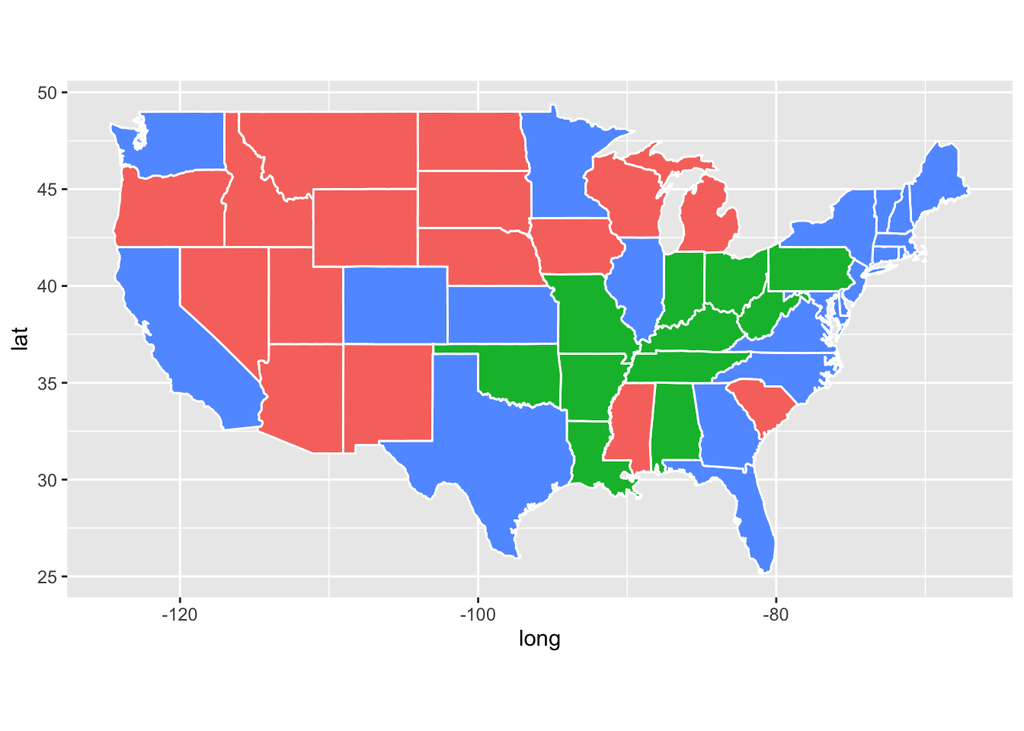

**8. We plot the graph for the census data using the total population.**

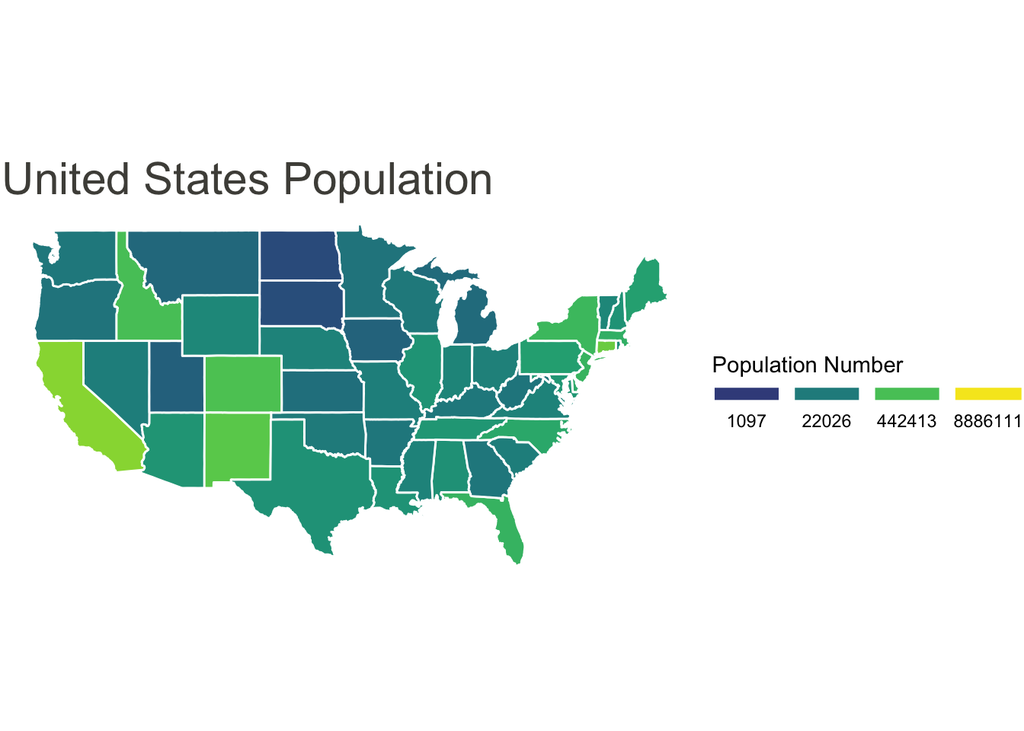

**9. We clean and aggregate the information in the census data which contains county-level census information.**

```r
# filter out any rows with missing values
census.clean = na.omit(census)

# convert {Men, Employed, VotingAgeCitizen} attributes to percentages
census.clean = census.clean %>%
  mutate(Men = 100*census.clean$Men/census.clean$TotalPop) %>%
  mutate(Employed = 100*census.clean$Employed/census.clean$TotalPop) %>%
  mutate(VotingAgeCitizen = 100*census.clean$VotingAgeCitizen/census.clean$TotalPop)

# compute Minority attribute by combining {Hispanic, Black, Native, Asian, Pacific}
census.clean = census.clean %>%
  mutate(minority = rowSums(census[,c(6,8,9,10,11)]))

# remove these variables after creating Minority
census.clean = select(census.clean, -c(Hispanic, Black, Native, Asian, Pacific))

# remove {Walk, PublicWork, Construction, Unemployment}
census.clean = select(census.clean, -c(Walk, PublicWork, Construction, Unemployment))
```

**10. Print out the cleaned census data.**

| State | County | TotalPop | Men | Women | White | VotingAgeCitizen | Poverty | Professional | Service | Office | Production | Drive | Carpool | Transit | OtherTransp | WorkAtHome | MeanCommute | Employed | PrivateWork | SelfEmployed | FamilyWork | minority |
| --- | --- | --- | --- | --- | --- | --- | --- | --- | --- | --- | --- | --- | --- | --- | --- | --- | --- | --- | --- | --- | --- | --- |
| AL | Autauga County | 55036 | 48.88 | 28137 | 75.4 | 74.53 | 13.7 | 35.3 | 18.0 | 23.2 | 15.4 | 86.0 | 9.6 | 0.1 | 1.3 | 2.5 | 25.8 | 43.81 | 74.1 | 5.6 | 0.1 | 22.8 |
| AL | Baldwin County | 203360 | 48.94 | 103833 | 83.1 | 76.40 | 11.8 | 35.7 | 18.2 | 25.6 | 10.8 | 84.7 | 7.6 | 0.1 | 1.1 | 5.6 | 27.0 | 44.02 | 80.7 | 6.3 | 0.1 | 15.4 |
| AL | Barbour County | 26201 | 53.34 | 12225 | 45.7 | 77.36 | 27.2 | 25.0 | 16.8 | 22.6 | 24.1 | 83.4 | 11.1 | 0.3 | 1.7 | 1.3 | 23.4 | 33.88 | 74.1 | 6.5 | 0.3 | 52.8 |
| AL | Bibb County | 22580 | 54.26 | 10329 | 74.6 | 78.22 | 15.2 | 24.4 | 17.6 | 19.7 | 22.4 | 86.4 | 9.5 | 0.7 | 1.7 | 1.5 | 30.0 | 36.19 | 76.0 | 6.3 | 0.3 | 24.8 |
| AL | Blount County | 57667 | 49.40 | 29177 | 87.4 | 73.72 | 15.6 | 28.5 | 12.9 | 23.3 | 19.5 | 86.8 | 10.2 | 0.1 | 0.4 | 2.1 | 35.0 | 37.07 | 83.9 | 4.0 | 0.1 | 10.9 |
| AL | Bullock County | 10478 | 53.60 | 4862 | 21.6 | 78.37 | 28.5 | 19.7 | 17.1 | 18.6 | 30.6 | 73.1 | 15.7 | 0.3 | 1.7 | 3.0 | 29.8 | 40.94 | 81.4 | 5.0 | 0.0 | 77.6 |

**Dimensionality reduction**

**11. Run PCA for the cleaned county level census data (with State and County excluded).**

```r
pca.census = prcomp(census.clean[,colnames(census.clean)!="State" &
                                   colnames(census.clean)!="County"&
                                   colnames(census.clean)!="Women"&
                                   colnames(census.clean)!="minority"&
                                   colnames(census.clean)!="TotalPop"],
                    scale=TRUE)
pc.county = pca.census$x[,c(1,2)]
```

Here, we choose to center and scale the features before running PCA is because we want to scale the variables to have standard deviation one, and scaling makes the results less complicated.  
We delete the “Women” and “TotalPop” column because it is colineared with “Men”, “minority” is colineared with “White”.

```
##   WorkAtHome SelfEmployed        Drive Professional   Production  PrivateWork
##       0.4286       0.3653       0.3589       0.3393       0.2889       0.2771
```

```
##            Drive       Production      PrivateWork          Poverty
##         -0.35886         -0.28893         -0.27714         -0.23543
##      MeanCommute           Office          Service          Carpool
##         -0.18175         -0.15340         -0.08843         -0.06468
## VotingAgeCitizen              Men
##          0.02701          0.07154
```

The features that have opposite signs are “Drive”, “Production”, “Privatework”, “Poverty”, “MeanCommute”, “Office”, “Service”, and “Carpool”.  
This means that there is a negative correlation of the variables in the first PC. For example, with an increasing of one of the negative-sign features, there is a decrease in the response.

**12. Determine the number of minimum number of PCs needed to capture 90% of the variance for the analysis.**

**Plot of proportion of variance explained by each component:**

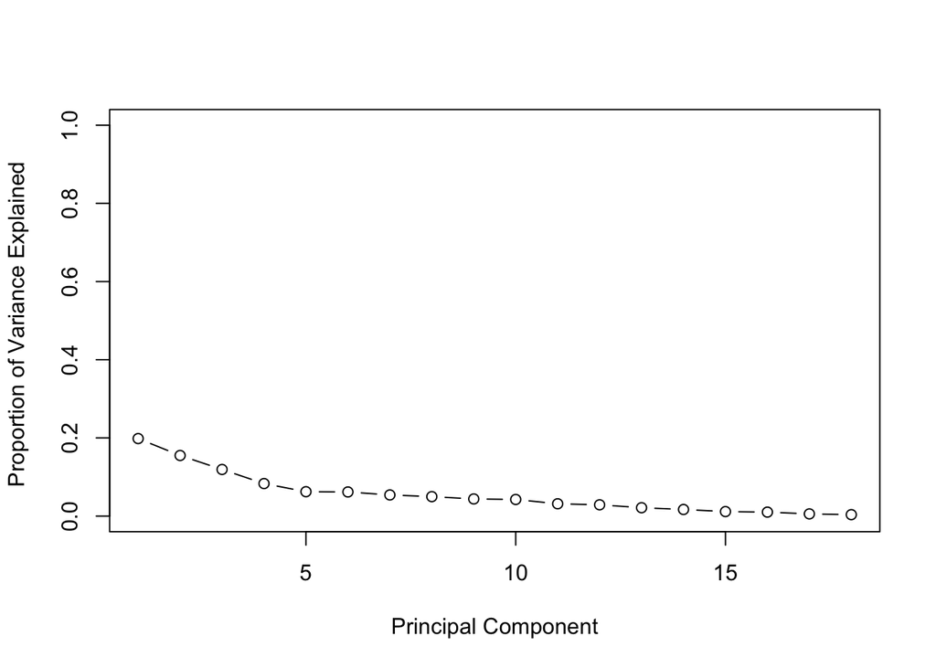

**Plot of proportion of variance explained by cumulative PVE:**

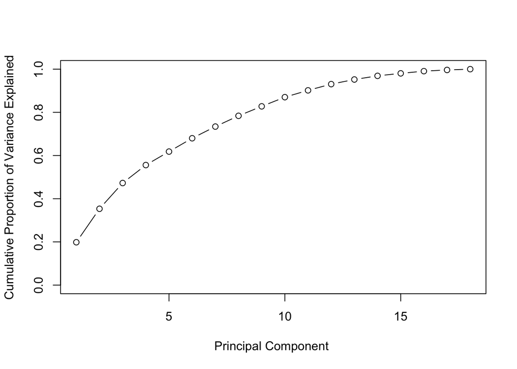

We need 11 PCs in order to explain 90% of the total variation in the data.

**Clustering**

**13. With census.clean (with State and County excluded), perform hierarchical clustering with complete linkage.**  
**Hierarchical Clustering for 10 clusters:**

```
## clust1
##    1    2    3    4    5    6    7    8    9   10
## 2789  245   73    2   12    1    2    5   12    1
```

```
## [1] 2
```

For hierarchical clustering with 10 cluster, we observe that “Santa Barbara County” is in cluster 2.

**First 2 Principal Componets**  
Then we use the first 2 principal components from pc.county as inputs instead of the original features to run hierarchical clustering algorithm again.

```
## clust2
##    1    2    3    4    5    6    7    8    9   10
## 1490  432   99  533  461   18   83    1   11   14
```

```
## [1] 5
```

For clustering the first 2 principal components with 10 cluster, we observe that “Santa Barbara County” is in cluster 5.

Apparently, using the first 2 principal components include more information related to “Santa Barbara County”. As a result, the second method seems to put “Santa Barbara County” in a more appropriate cluster.

**Modeling**

Question we want to answer: *Can we use census information as well as the education information in a county to predict the level of poverty in that county?*

```r
# we join the two data sets
all = census.clean %>%
  left_join(education, by = c("State"="State", "County"="County")) %>%
  na.omit
```

**14. Transform the variable Poverty into a binary categorical variable with two levels: 1 if Poverty is greater than 20, and 0 if Poverty is smaller than or equal to 20. Remove features that you think are uninformative in classification tasks.**

```r
all = all %>%
  mutate(Poverty = factor(as.integer(Poverty > 20), level=c(0,1)))
all = all %>%
  select(c("Men","Poverty","Professional","Employed","PrivateWork","SelfEmployed","FamilyWork","minority","Percent of adults with less than a high school diploma, 2015-19","Percent of adults with a high school diploma only, 2015-19","Percent of adults completing some college or associate's degree, 2015-19","Percent of adults with a bachelor's degree or higher, 2015-19"))
colnames(all) = make.names(colnames(all))
```

We then partition the dataset into $80%$ training and $20%$ test data.

The following code to define 10 cross-validation folds:

```r
set.seed(123)
nfold <- 10
folds <- sample(cut(1:nrow(all.tr), breaks=nfold, labels=FALSE))
```

The following is the error rate function. And the object records is used to record the classification performance of each method in the subsequent problems.

```r
calc_error_rate = function(predicted.value, true.value){
  return(mean(true.value!=predicted.value))
}
records = matrix(NA, nrow=3, ncol=2)
colnames(records) = c("train.error","test.error")
rownames(records) = c("tree","logistic","lasso")
```

**Classification**

**15. Decision Tree**

**Tree before pruning:**

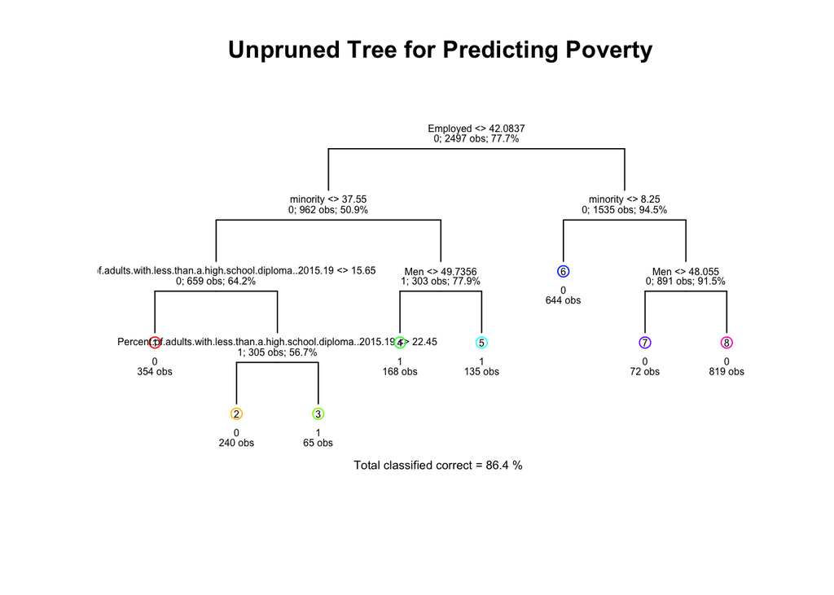

**Tree After Pruning:**

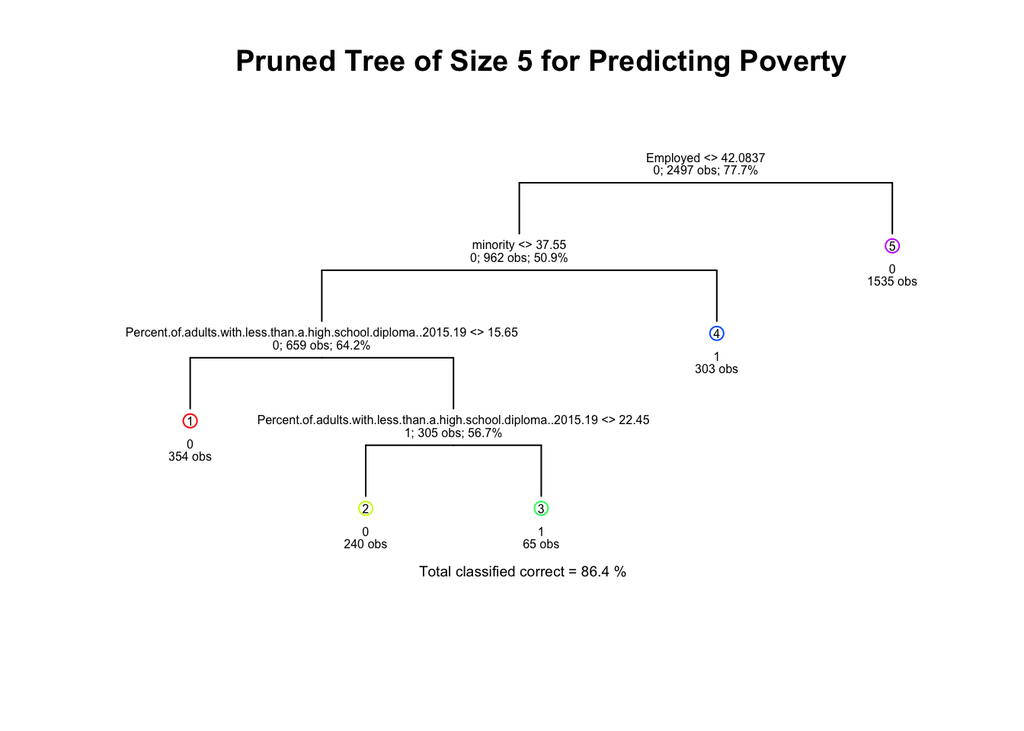

The *Training Error Rate* is 0.1358.

The *test Error Rate* is 0.1472.

Both Unpruned and Pruned Tree were first splitted by the “Employed” feature which implies that it could be the most influential variable in predicting Poverty.  
Overall, the Pruned Tree tells us that unemployed minorities with lower education level may result in Poverty.

**16. Logistic Regression**  
We first fit a logistic regression model.

```
##
## Call:
## glm(formula = Poverty ~ ., family = "binomial", data = all.tr)
##
## Deviance Residuals:
##    Min      1Q  Median      3Q     Max
## -2.340  -0.458  -0.196  -0.045   3.484
##
## Coefficients:
##                                                                           Estimate
## (Intercept)                                                              144.28969
## Men                                                                       -0.34884
## Professional                                                              -0.02790
## Employed                                                                  -0.26022
## PrivateWork                                                               -0.10797
## SelfEmployed                                                              -0.13657
## FamilyWork                                                                -0.16249
## minority                                                                   0.01905
## Percent.of.adults.with.less.than.a.high.school.diploma..2015.19           -0.98173
## Percent.of.adults.with.a.high.school.diploma.only..2015.19                -1.06762
## Percent.of.adults.completing.some.college.or.associate.s.degree..2015.19  -1.17431
## Percent.of.adults.with.a.bachelor.s.degree.or.higher..2015.19             -1.02735
##                                                                          Std. Error
## (Intercept)                                                               116.01155
## Men                                                                         0.02965
## Professional                                                                0.02104
## Employed                                                                    0.01914
## PrivateWork                                                                 0.01425
## SelfEmployed                                                                0.02789
## FamilyWork                                                                  0.17422
## minority                                                                    0.00421
## Percent.of.adults.with.less.than.a.high.school.diploma..2015.19             1.16024
## Percent.of.adults.with.a.high.school.diploma.only..2015.19                  1.15975
## Percent.of.adults.completing.some.college.or.associate.s.degree..2015.19    1.16027
## Percent.of.adults.with.a.bachelor.s.degree.or.higher..2015.19               1.15929
##                                                                          z value
## (Intercept)                                                                 1.24
## Men                                                                       -11.77
## Professional                                                               -1.33
## Employed                                                                  -13.59
```

[output cut: 29 more lines]

```
## minority                                                                 ***
## Percent.of.adults.with.less.than.a.high.school.diploma..2015.19
## Percent.of.adults.with.a.high.school.diploma.only..2015.19
## Percent.of.adults.completing.some.college.or.associate.s.degree..2015.19
## Percent.of.adults.with.a.bachelor.s.degree.or.higher..2015.19
## ---
## Signif. codes:  0 '***' 0.001 '**' 0.01 '*' 0.05 '.' 0.1 ' ' 1
##
## (Dispersion parameter for binomial family taken to be 1)
##
##     Null deviance: 2650.6  on 2496  degrees of freedom
## Residual deviance: 1457.0  on 2485  degrees of freedom
## AIC: 1481
##
## Number of Fisher Scoring iterations: 6
```

The significant variables are “Men”, “Employed”, “PrivateWork”, “SelfEmployed”, “minority”.  
“Employed” and “minority” seem to have consistency comparing to the influential variables in the Pruned Tree.  
Increasing “Employed” by 1-unit implies multiply the odds by $e^{coefficient-estimate-of-Employed}$.  
Increasing “minority” by 1-unit implies multiply the odds by $e^{coefficient-estimate-of-minority}$.

After calculating the error rates, the Records Matrix is:

```
##          train.error test.error
## tree          0.1358     0.1472
## logistic      0.1237     0.1376
## lasso             NA         NA
```

**17. Now Consider a Lasso Regression Model**  
We first fit the model to select the best tuning parameter $\lambda$, and

the optimal value tuning parameter $\lambda$ is 2^{-4}.

The coefficients of lasso regression are:

```
## 12 x 1 sparse Matrix of class "dgCMatrix"
##                                                                                s1
## (Intercept)                                                              40.91527
## Men                                                                      -0.34644
## Professional                                                             -0.02548
## Employed                                                                 -0.25754
## PrivateWork                                                              -0.10669
## SelfEmployed                                                             -0.13537
## FamilyWork                                                               -0.15155
## minority                                                                  0.01909
## Percent.of.adults.with.less.than.a.high.school.diploma..2015.19           0.04750
## Percent.of.adults.with.a.high.school.diploma.only..2015.19               -0.03747
## Percent.of.adults.completing.some.college.or.associate.s.degree..2015.19 -0.14345
## Percent.of.adults.with.a.bachelor.s.degree.or.higher..2015.19             .
```

The penalized logistic regression does model selection and takes less predicting variables than the unpenalized logistic regression.  
Higher education has a less significant negative influence on Poverty than the postive influence of the lower education has on Poverty.

**18. ROC curve for the decision tree, logistic regression and LASSO logistic regression using predictions on the test data.**  
(Red is Decision Tree, Blue is Logistic Regression, Pink is Lasso Regression)

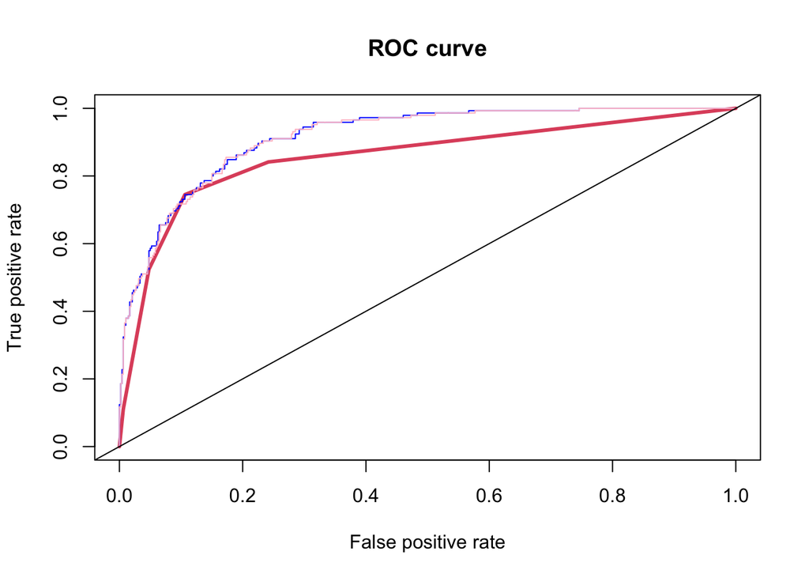

The current error rates for Decision Tree, Logistic Regression, and Lasso Regression:

```
##          train.error test.error
## tree          0.1358     0.1472
## logistic      0.1237     0.1376
## lasso         0.1241     0.1408
```

According to the error rate records matrix, we can see that logistic regression with the lowest test error rate, has a better performance than the other two methods.  
Decision Tree and Lasso have higher test error rate.  
If we are more interested in predicting the Poverty using census data, logistic regression is a good method to use because in the model we fit previously, all the significant variables are from census data.  
Decision Tree seems to be less appropriate for predicting Poverty in this situation, while Logistic and Lasso Regression turns out to provide a relatively better AUC.

**19. Other ways to Fit a Model**

**(a) Fitting the model using Boosting**  
We perform a boosting model and produce a relative influence plot and also outputs the relative influence statistics.

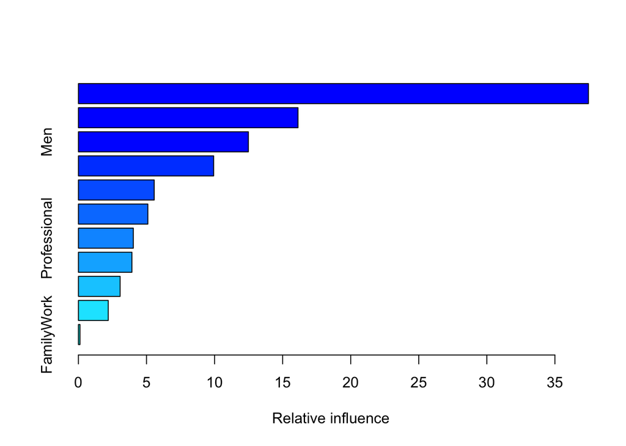

|  | var | rel.inf |
| --- | --- | --- |
| Employed | Employed | 37.4622 |
| Percent.of.adults.with.less.than.a.high.school.diploma..2015.19 | Percent.of.adults.with.less.than.a.high.school.diploma..2015.19 | 16.1266 |
| Men | Men | 12.4835 |
| minority | minority | 9.9318 |
| Percent.of.adults.with.a.bachelor.s.degree.or.higher..2015.19 | Percent.of.adults.with.a.bachelor.s.degree.or.higher..2015.19 | 5.5663 |
| Percent.of.adults.completing.some.college.or.associate.s.degree..2015.19 | Percent.of.adults.completing.some.college.or.associate.s.degree..2015.19 | 5.1002 |
| Professional | Professional | 4.0331 |
| PrivateWork | PrivateWork | 3.9303 |
| SelfEmployed | SelfEmployed | 3.0617 |
| Percent.of.adults.with.a.high.school.diploma.only..2015.19 | Percent.of.adults.with.a.high.school.diploma.only..2015.19 | 2.1913 |

[output cut: 1 more lines]

From the above graph, we can see that “Employed” is is by far the most important variable. Comparing to the other variables, “Employed” has a relative relative influence to the response value “Poverty”.

Then we would like to know how does this boosting model perform by calculating its error rate using training and testing data.

```
##          train.error test.error
## tree          0.1358     0.1472
## logistic      0.1237     0.1376
## lasso         0.1241     0.1408
## boosting      0.1005     0.1376
```

LOOCV to find the best K:

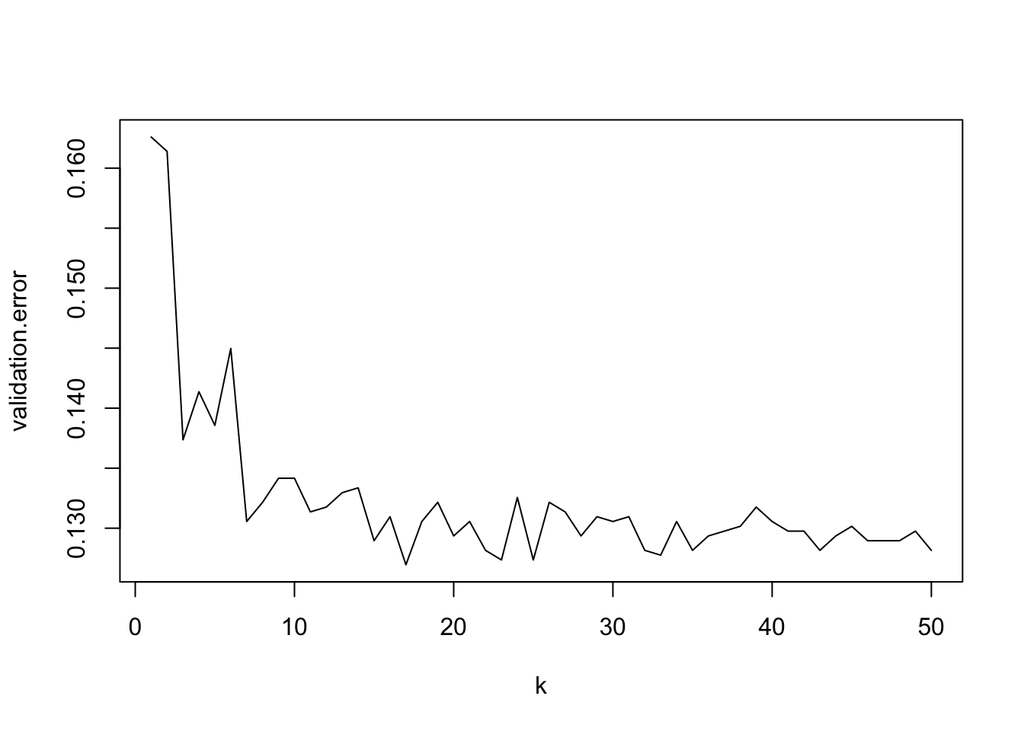

Then we choose the number of k to be:

```
## [1] 17
```

Confusion Matrix of Training Data:

```
##          true
## predicted    0    1
##         0 1861  208
##         1   79  349
```

Confusion Matrix of Test Data:

```
##          true
## predicted   0   1
##         0 451  63
##         1  29  82
```

Now we can see the error rate for all the methods we used is:

```
##          train.error test.error
## tree          0.1358     0.1472
## logistic      0.1237     0.1376
## lasso         0.1241     0.1408
## boosting      0.1005     0.1376
## knn           0.1149     0.1472
```

**Comparison**  
According to the new error rate record matrix, while logistic regression and boosting have the same test error rate, boosting seems to have a lower training error rate which may implies overfitting in the boosting model compare to the logistic regression model.  
And interestingly, Decision tree and KNN have the same test error as well, and similarly, KNN seems to have a lower training error rate which may also implies overfitting in the KNN model compare to the decision Tree model.  
Overall, Logistic Regression gives us a better performance on this data set.

**20. Interesting Questions**

**(a) First, we want to use Boosting model to predict the actual value of Poverty by County, and compare it with the Boosting model in the classification setting.**

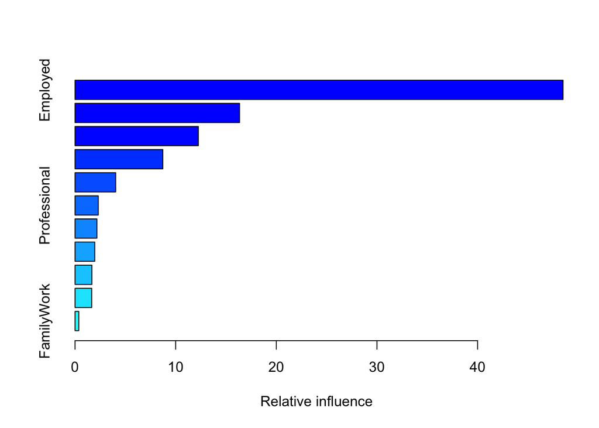

|  | var | rel.inf |
| --- | --- | --- |
| Employed | Employed | 48.4946 |
| `Percent of adults with less than a high school diploma, 2015-19` | `Percent of adults with less than a high school diploma, 2015-19` | 16.3486 |
| minority | minority | 12.2522 |
| Men | Men | 8.7223 |
| PrivateWork | PrivateWork | 4.0392 |
| Professional | Professional | 2.3097 |
| `Percent of adults with a bachelor's degree or higher, 2015-19` | `Percent of adults with a bachelor's degree or higher, 2015-19` | 2.1741 |
| SelfEmployed | SelfEmployed | 1.9592 |
| `Percent of adults completing some college or associate's degree, 2015-19` | `Percent of adults completing some college or associate's degree, 2015-19` | 1.6746 |
| `Percent of adults with a high school diploma only, 2015-19` | `Percent of adults with a high school diploma only, 2015-19` | 1.6539 |

[output cut: 1 more lines]

The ROC curve for Logistic Boosting and Regression Boosting:  
(Blue for regression, and red for logistic)

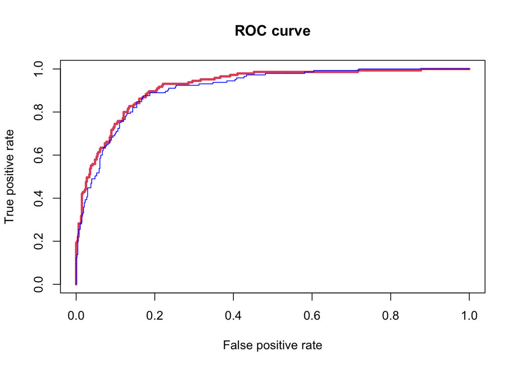

The AUC for Logistic Boosting is 0.9202.  
The AUC for Regression Boosting is 0.9101.

Apparently, we obtain a higher AUC value for the binary response variable than the actual response while using the same modeling method, which is quite different from our previous assumption of the error rate for the result. One of possible reason could be this problem is more of a identification problem, which may works better with Classification Algorithms.  
Specifically for the current dataset we are using, we would prefer classification models because this dataset we use is basically identification problem where we want to predict if there is Poverty exists.  
On the other hand, if we consider problems (not in the datasets we currently used) that predict house pricing might perform better using regression method, because house price prediction is a continuous data and the output variable is continuous nature or real value.  
As a result, choosing Regression or Classification method is usually based on what kind of output variables we want to predict.

After calculate all the training and test rate of the various models, we want to find out most related variables in order to improve our models and make a better prediction.  
Since we did not use “TotalPop” as one of of predicting variables in fitting the models to predict “Poverty”, we first want to find out how the Total Population related to the percentage of Poverty in different States.

**(b) Display the Poverty level of each State using the ggplot and compare it with the Population Level graph. Will more population result in a higher Poverty level?**  
In this case, we will use the census.clean without make the Poverty column into level 0 and 1 (using the actual vales), then plot the graph.  
The graph is shown below with comparison to the previous graph of Population:

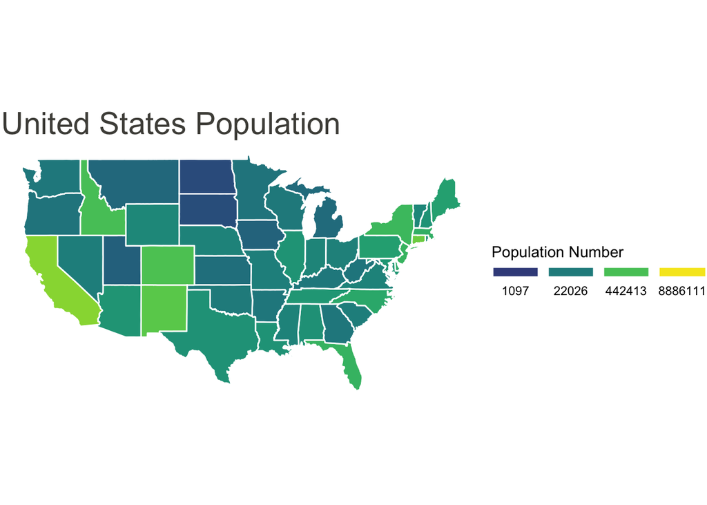

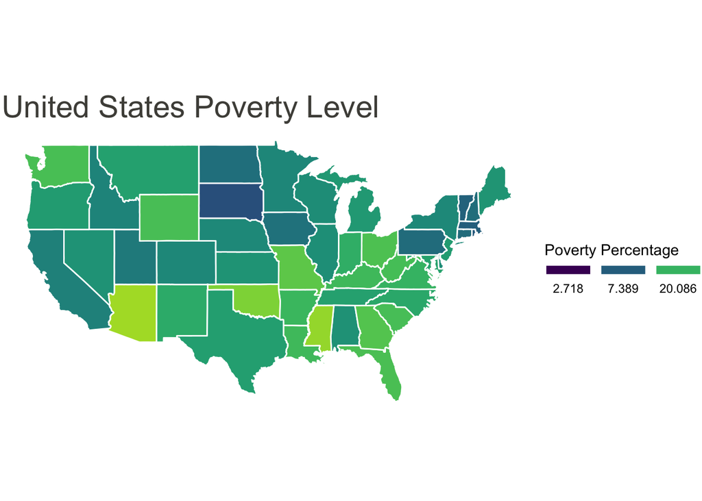

**(c) Then, we want to use Bootstrap Method to discuss the correlation between Poverty and three variables we are interested in.**

**1. Poverty & Total Population**  
As we discussed in the previous section, we want to see if there is correlation between Poverty and Total Population.

```
##
## ORDINARY NONPARAMETRIC BOOTSTRAP
##
##
## Call:
## boot(data = all1, statistic = fc1, R = 500)
##
##
## Bootstrap Statistics :
##     original    bias    std. error
## t1* -0.06665 -0.002727     0.01647
```

The Characteristic of the Coefficient:

```
## [1] -0.12514 -0.03017
```

```
## [1] -0.06938
```

```
## [1] 0.01647
```

Plot of Bootstrapping:

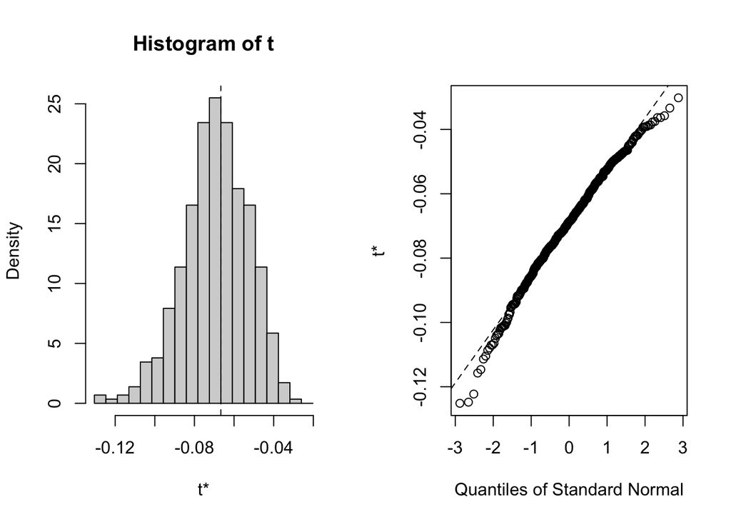

Confidence Interval of Coefficient:

```
## BOOTSTRAP CONFIDENCE INTERVAL CALCULATIONS
## Based on 500 bootstrap replicates
##
## CALL :
## boot.ci(boot.out = bootcorr_pop, type = c("norm"))
##
## Intervals :
## Level      Normal
## 95%   (-0.0962, -0.0316 )
## Calculations and Intervals on Original Scale
```

Range of the correlation coefficient: [-0.12514 -0.03017]  
Mean: -0.06938  
Standard deviation: 0.01647  
95% confidence interval: [-0.0962, -0.0316]

**2. Poverty & Percent of adults with less than a high school diploma, 2015-19**  
Next, we want to see how correlated are Poverty with “Percent of adults with less than a high school diploma, 2015-19”, which was shown to have strong influence in boosting method above.

Characteristic of Coefficient:

```
## [1] 0.5606 0.6602
```

```
## [1] 0.6115
```

```
## [1] 0.01544
```

Plot of Bootstrapping:

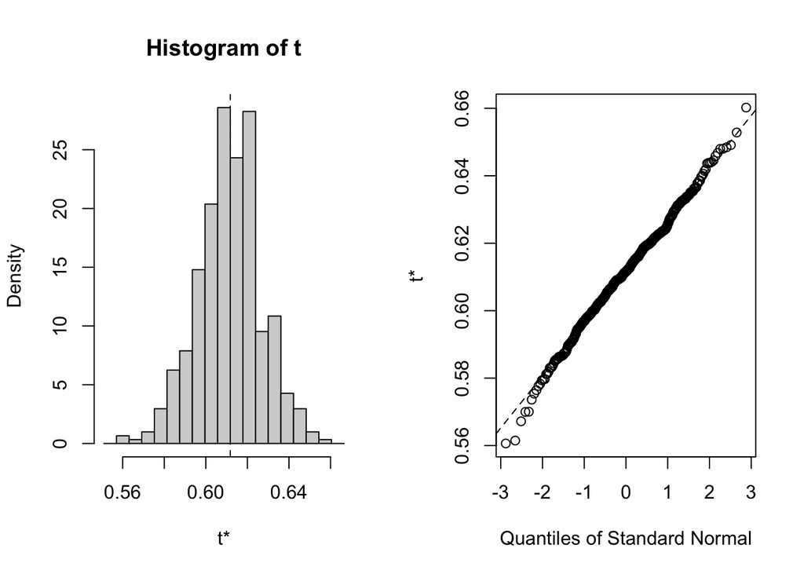

Confidence Interval of Coefficient:

```
## BOOTSTRAP CONFIDENCE INTERVAL CALCULATIONS
## Based on 500 bootstrap replicates
##
## CALL :
## boot.ci(boot.out = bootcorr_ed, type = c("norm"))
##
## Intervals :
## Level      Normal
## 95%   ( 0.5817,  0.6423 )
## Calculations and Intervals on Original Scale
```

As we can see, the range of the correlation coefficient is from 0.5606 to 0.6602, and the 95% CI is from 0.5817 to 0.6423.  
The statistics suggest that these two variables have some strong positive correlation, which implies that a low education level has a positive influence on poverty.

**3. Poverty & Employed**  
Employed also shown to be a strong factor in boosting method, so we performed boostrap on it as well:

Characteristic of Coefficient:

```
## [1] -0.7348 -0.6734
```

```
## [1] -0.7075
```

```
## [1] 0.01097
```

Plot of Bootstrapping:

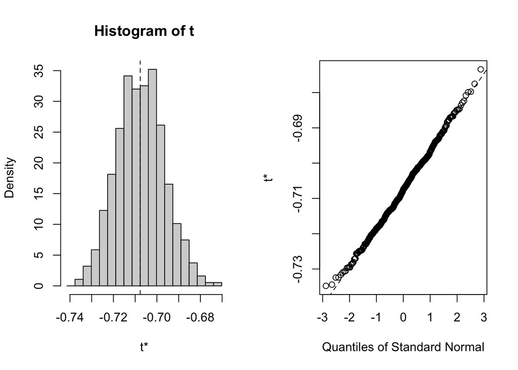

Confidence Interval of Coefficient:

```
## BOOTSTRAP CONFIDENCE INTERVAL CALCULATIONS
## Based on 500 bootstrap replicates
##
## CALL :
## boot.ci(boot.out = bootcorr_em, type = c("norm"))
##
## Intervals :
## Level      Normal
## 95%   (-0.7293, -0.6863 )
## Calculations and Intervals on Original Scale
```

As we can see, the range of the correlation coefficient is from -0.7348 to -0.6734, and the 95% CI is from -0.7293 to -0.6863.  
The statistics suggest that these two variables have some strong negative correlation, which implies that employed groups are less possible to have poverty.

**21. Interpret and discuss any overall insights gained in this analysis and possible explanations.**

**a.** We use the Regression Boosting Model to predict the percentage of the Poverty and compare with the actual percentage of Poverty.

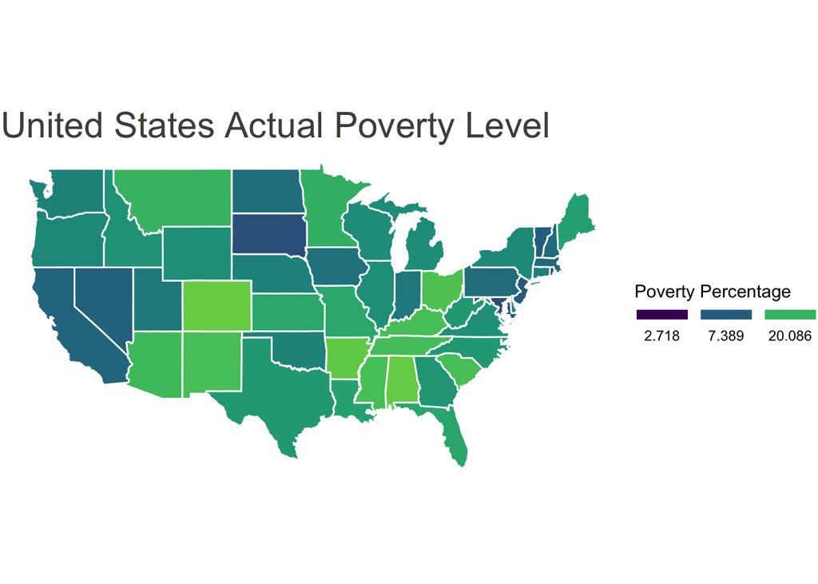

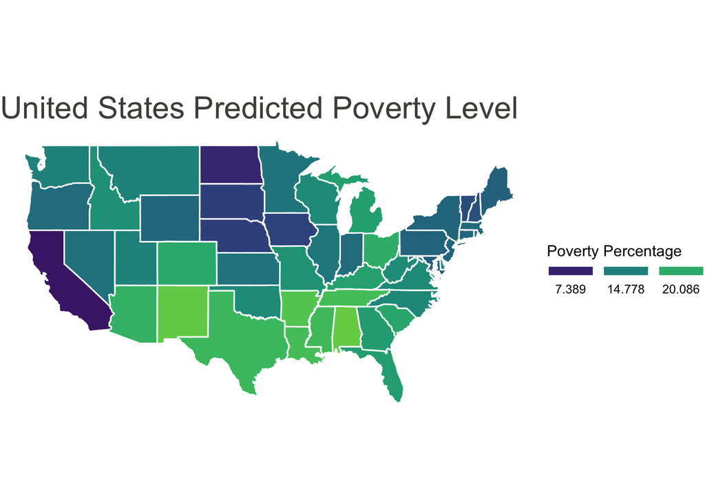

**b.** One result that we did not expected was the influence of higher education level has a lighter influence on poverty than the lower education level. Before reading the result of LASSO regression, the only thing we knew was LASSO can help to reduce coefficient amount, but now we learned that it could also show some relative significance between coefficients with similar measure.

**d.** We might be able to compare some other aspects that have relations with poverty from some industry data. In this data set, we complied several variables from census and education, which mainly focused on the lifestyle and identification of the population (race, transportation, jobs, gender, and education background). In addition to that, for example, the population in the US who are in the Medicaid insurance group, which is a public program designed for the low-income population. The industry data tends to have a cleaner structure and has a more direct relation with the financial situation. Other industry data examples could be government financial aid and support programs.